# ESM 206 Fall 2019 - Lab 10

Allison Horst

11/29/2019

## Objectives:

- Multiple linear regression
- Check assumptions w/diagnostic plots
- Make predictions with new data
- Some other fun things (beepr, praise, sf, gganimate)

### 1. Multiple linear regression

Here, we’ll be modeling housing price based on house characteristics using data from SLO home sales.

- Read in slo_homes.csv file and explore
- Only keep observations for San Luis Obispo, Atascadero and Arroyo Grande

```r
homes <- read_csv("slo_homes.csv") %>%
  clean_names() %>%
  filter(city %in% c("San Luis Obispo", "Atascadero", "Arroyo Grande"))
praise()
```

```
## [1] "You are unreal!"
```

Some exploring: look at correlations between numeric variables

```r
homes_cor <- cor(homes[2:6])
homes_cor
```

```
##                     price    bedrooms bathrooms     sq_ft price_per_sq_ft
## price           1.0000000  0.31152578 0.4991453 0.6618575      0.73664029
## bedrooms        0.3115258  1.00000000 0.7519186 0.6960233     -0.09994633
## bathrooms       0.4991453  0.75191865 1.0000000 0.8046112      0.07624770
## sq_ft           0.6618575  0.69602326 0.8046112 1.0000000      0.12549708
## price_per_sq_ft 0.7366403 -0.09994633 0.0762477 0.1254971      1.00000000
```

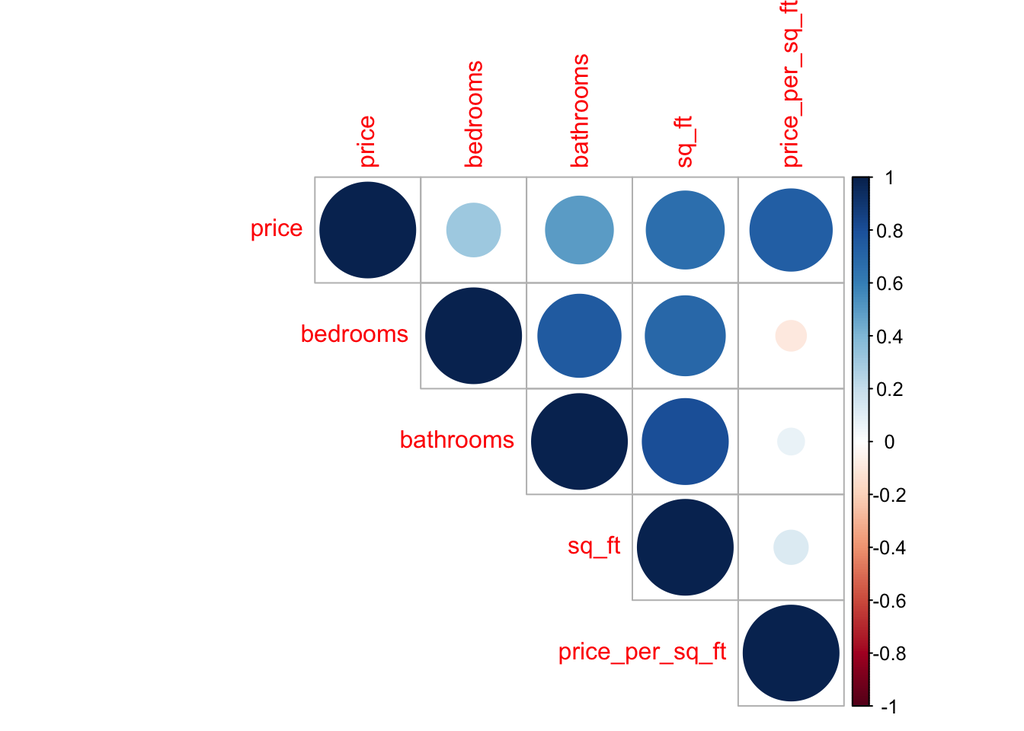

```r
corrplot(homes_cor,
         method = "circle",
         type = "upper")
```

```r
# Moderate correlations between numeric variables (no concern about multicollinearity here from a correlation value standpoint, but there may be some conceptual overlap between variables)

praise()
```

```
## [1] "You are wonderful!"
```

```r
# See: names(praise_parts) for other things you can call in praise

# For example, customize it a bit
praise("You are totally ${adjective}! Super ${EXCLAMATION}!")
```

```
## [1] "You are totally priceless! Super UH-HU!"
```

But let’s start out using all variables we have:

```r
home_lm <- lm(price ~ city + bedrooms + bathrooms + sq_ft + status, data = homes)

# View it:
home_lm
```

```
##
## Call:
## lm(formula = price ~ city + bedrooms + bathrooms + sq_ft + status,
##     data = homes)
##
## Coefficients:
##         (Intercept)       cityAtascadero  citySan Luis Obispo
##            184130.9            -167396.4              31018.1
##            bedrooms            bathrooms                sq_ft
##           -161645.5              48692.0                389.1
##       statusRegular     statusShort Sale
##            303964.6             -19828.6
```

```r
summary(home_lm)
```

```
##
## Call:
## lm(formula = price ~ city + bedrooms + bathrooms + sq_ft + status,
##     data = homes)
##
## Residuals:
##     Min      1Q  Median      3Q     Max
## -843938 -115963  -12298  109718 3445077
##
## Coefficients:
##                       Estimate Std. Error t value Pr(>|t|)
## (Intercept)          184130.93  143368.84   1.284  0.20157
## cityAtascadero      -167396.39   78701.95  -2.127  0.03552 *
## citySan Luis Obispo   31018.14  114895.10   0.270  0.78766
## bedrooms            -161645.51   49414.32  -3.271  0.00141 **
## bathrooms             48692.04   52408.63   0.929  0.35476
## sq_ft                   389.12      53.17   7.318 3.43e-11 ***
## statusRegular        303964.64  105942.81   2.869  0.00488 **
## statusShort Sale     -19828.56   86335.35  -0.230  0.81875
## ---
## Signif. codes:  0 '***' 0.001 '**' 0.01 '*' 0.05 '.' 0.1 ' ' 1
##
## Residual standard error: 380600 on 117 degrees of freedom
## Multiple R-squared:  0.5682, Adjusted R-squared:  0.5424
## F-statistic:    22 on 7 and 117 DF,  p-value: < 2.2e-16
```

Well that’s kind of a nightmare to look at. And putting it into a table could be really challenging. Enter, the `stargazer` package.

```r
stargazer(home_lm, type = "html")
```

|  | *Dependent variable:* |
| --- | --- |
|  | price |
| cityAtascadero | -167,396.400** |
|  | (78,701.950) |
| citySan Luis Obispo | 31,018.140 |
|  | (114,895.100) |
| bedrooms | -161,645.500*** |
|  | (49,414.320) |
| bathrooms | 48,692.040 |
|  | (52,408.630) |
| sq_ft | 389.120*** |
|  | (53.171) |
| statusRegular | 303,964.600*** |
|  | (105,942.800) |
| statusShort Sale | -19,828.560 |
|  | (86,335.350) |
| Constant | 184,130.900 |
|  | (143,368.800) |
| Observations | 125 |
| R<sup>2</sup> | 0.568 |
| Adjusted R<sup>2</sup> | 0.542 |
| Residual Std. Error | 380,586.300 (df = 117) |
| F Statistic | 21.997*** (df = 7; 117) |
| *Note:* | p<0.1; p<0.05; p<0.01 |

Let’s answer a few questions:

- How do we interpret each of these variables?
- What is the reference level for city?
- What does NOT make sense here, that might be multiply described by another variable in the model?

Try another version of the model:

```r
home_lm2 <- lm(price ~ city + sq_ft + status, data = homes)
```

And check out the results:

```r
stargazer(home_lm2, type = "html") # And you can customize...
```

|  | *Dependent variable:* |
| --- | --- |
|  | price |
| cityAtascadero | -182,586.900** |
|  | (80,683.440) |
| citySan Luis Obispo | 70,278.970 |
|  | (115,846.300) |
| sq_ft | 325.028*** |
|  | (31.538) |
| statusRegular | 315,441.300*** |
|  | (109,749.700) |
| statusShort Sale | 31,284.440 |
|  | (87,356.110) |
| Constant | -105,820.700 |
|  | (118,697.400) |
| Observations | 125 |
| R<sup>2</sup> | 0.527 |
| Adjusted R<sup>2</sup> | 0.507 |
| Residual Std. Error | 395,084.400 (df = 119) |
| F Statistic | 26.491*** (df = 5; 119) |
| *Note:* | p<0.1; p<0.05; p<0.01 |

You can also use stargazer for multiple model comparisons:

```r
stargazer(home_lm, home_lm2, type = "html")
```

|  | *Dependent variable:* |  |
| --- | --- | --- |
|  | price |  |
|  | (1) | (2) |
| cityAtascadero | -167,396.400** | -182,586.900** |
|  | (78,701.950) | (80,683.440) |
| citySan Luis Obispo | 31,018.140 | 70,278.970 |
|  | (114,895.100) | (115,846.300) |
| bedrooms | -161,645.500*** |  |
|  | (49,414.320) |  |
| bathrooms | 48,692.040 |  |
|  | (52,408.630) |  |
| sq_ft | 389.120*** | 325.028*** |
|  | (53.171) | (31.538) |
| statusRegular | 303,964.600*** | 315,441.300*** |
|  | (105,942.800) | (109,749.700) |
| statusShort Sale | -19,828.560 | 31,284.440 |
|  | (86,335.350) | (87,356.110) |
| Constant | 184,130.900 | -105,820.700 |
|  | (143,368.800) | (118,697.400) |
| Observations | 125 | 125 |
| R<sup>2</sup> | 0.568 | 0.527 |
| Adjusted R<sup>2</sup> | 0.542 | 0.507 |
| Residual Std. Error | 380,586.300 (df = 117) | 395,084.400 (df = 119) |
| F Statistic | 21.997*** (df = 7; 117) | 26.491*** (df = 5; 119) |
| *Note:* | p<0.1; p<0.05; p<0.01 |  |

### 2. Exploring diagnostics

We can use the diagnostic plots to check assumptions about residuals, e.g.:

- Constant variance of residuals?
- Normally distributed residuals?
- Also check: any notable outliers?

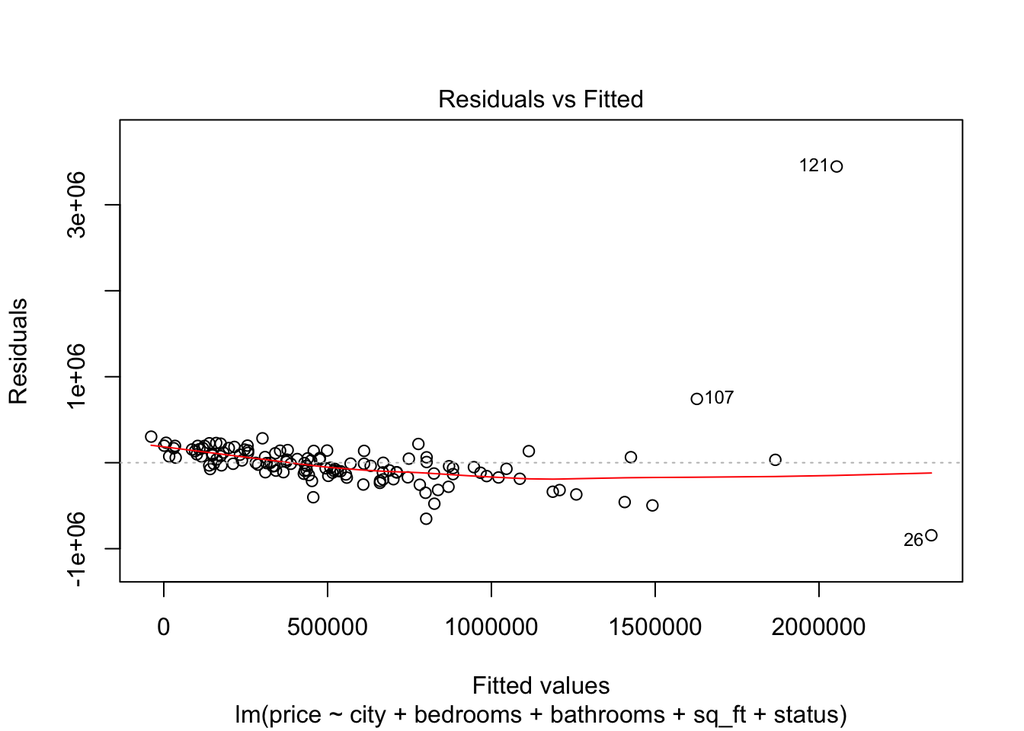

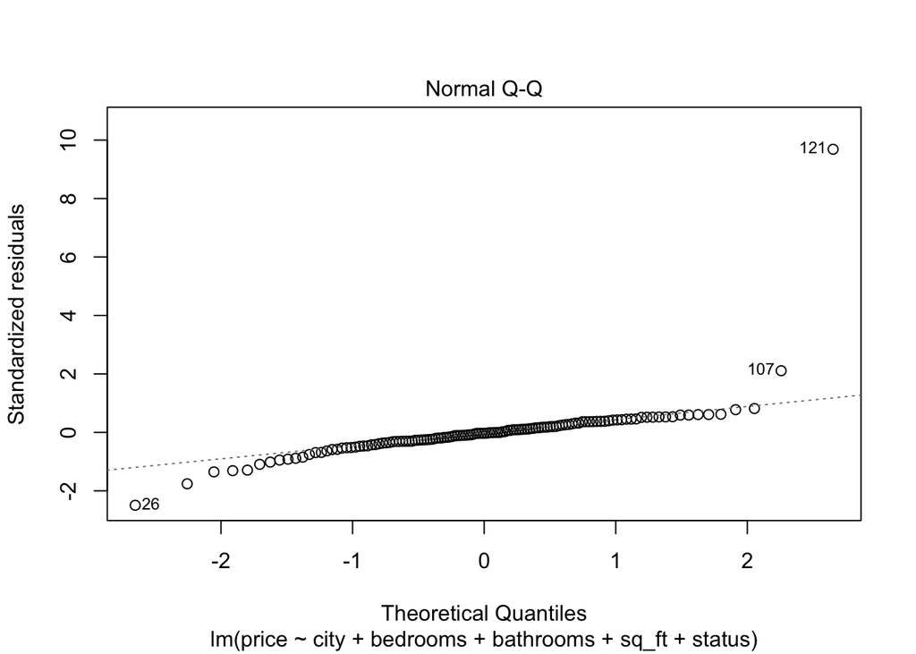

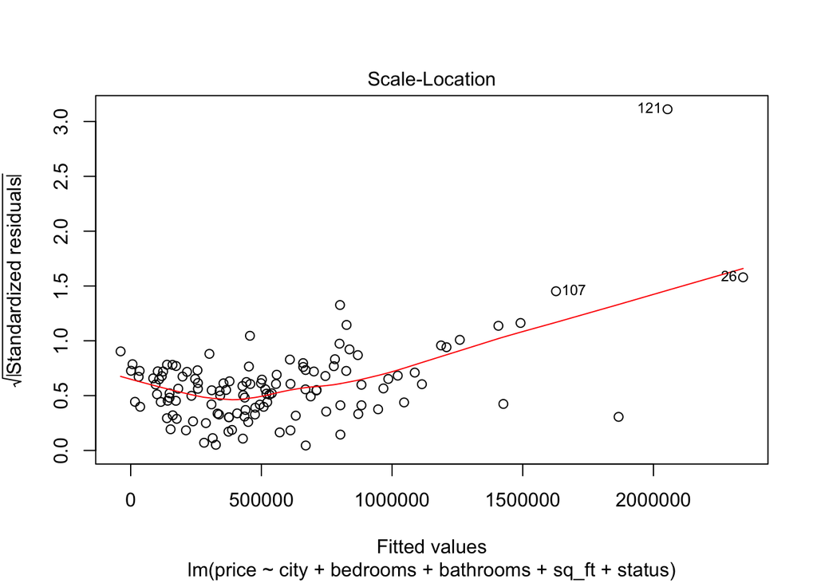

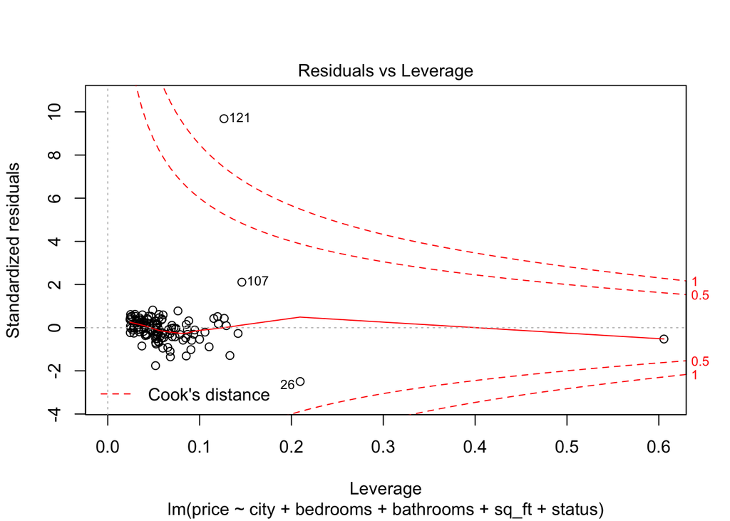

```r
plot(home_lm)
```

### 3. Predictions for home price with multiple variables

First, we’ll make a new data frame containing all variables that `home_lm2` needs to make a prediction:

```r
new_df <- data.frame(
  city = rep(c("San Luis Obispo", "Arroyo Grande", "Atascadero"), each = 10),
  sq_ft = rep(seq(0, 5000, length = 10)),
  status = rep("Regular", 30)
)

new_df
```

```
##               city     sq_ft  status
## 1  San Luis Obispo    0.0000 Regular
## 2  San Luis Obispo  555.5556 Regular
## 3  San Luis Obispo 1111.1111 Regular
## 4  San Luis Obispo 1666.6667 Regular
## 5  San Luis Obispo 2222.2222 Regular
## 6  San Luis Obispo 2777.7778 Regular
## 7  San Luis Obispo 3333.3333 Regular
## 8  San Luis Obispo 3888.8889 Regular
## 9  San Luis Obispo 4444.4444 Regular
## 10 San Luis Obispo 5000.0000 Regular
## 11   Arroyo Grande    0.0000 Regular
## 12   Arroyo Grande  555.5556 Regular
## 13   Arroyo Grande 1111.1111 Regular
## 14   Arroyo Grande 1666.6667 Regular
```

[output cut: 16 more lines]

Then, use the `predict()` function to find the predicted home prices for each combination in `new_df`:

```r
# Make the predictions using new_df:
predict_df <- predict(home_lm2, newdata = new_df)

# Then bind predictions together with new_df:
full_df <- data.frame(new_df, predict_df)
```

### 4. Visualize it!

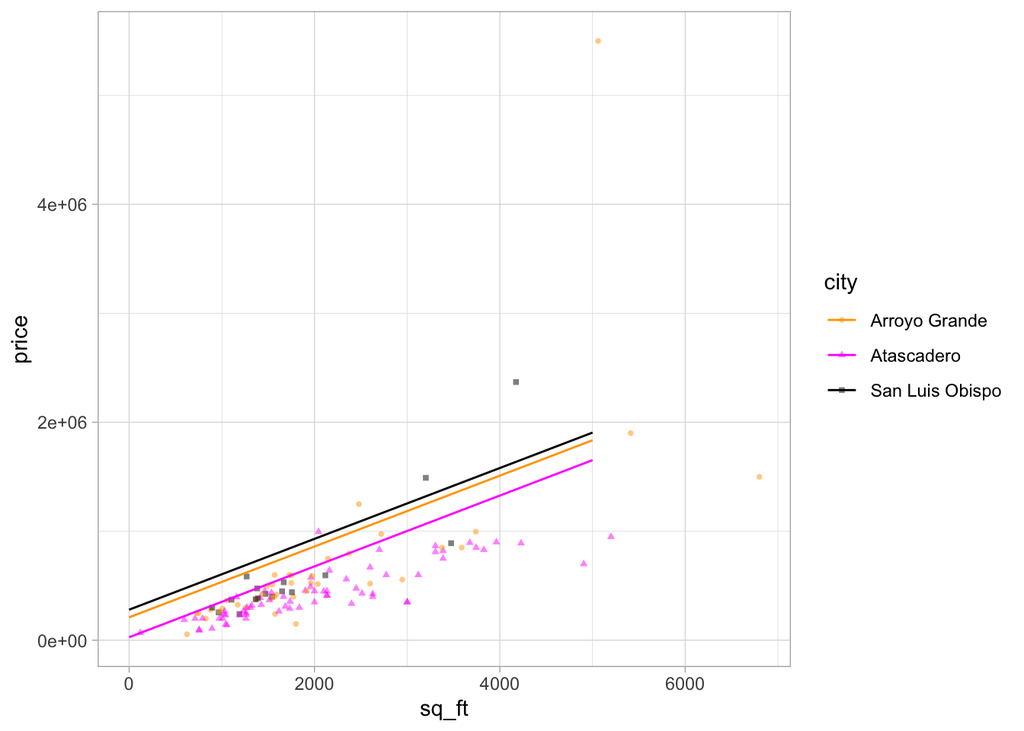

```r
ggplot() +
  geom_point(data = homes,
             aes(x = sq_ft,
                 y = price,
                 color = city,
                 pch = city),
             size = 1,
             alpha = 0.5) +
  geom_line(data = full_df,
            aes(x = sq_ft,
                y = predict_df,
                color = city)) +
  scale_color_manual(values = c("orange", "magenta", "black")) +
  theme_light()
```

### 5. Compare AIC values

…but statistics are not substitute for judgement!

```r
AIC(home_lm)
```

```
## [1] 3576.834
```

```r
AIC(home_lm2)
```

```
## [1] 3584.3
```

```r
# Pretty close, but the first model has a lower AIC. Should I pick the first model just based on AIC? NO!
```

### 6. A little map teaser

Data source: https://nid.sec.usace.army.mil/ords/f?p=105:19:14606625072661::NO:::

Get and check out the CA dams data:

```r
dams <- read_csv("ca_dams.csv") %>%
  clean_names() %>%
  drop_na(latitude) %>%
  drop_na(longitude) %>%
  drop_na(year_completed)
```

Then make sure R understands that latitude & longitude are spatial coordinates using `sf::st_as_sf()`:

```r
dams_sf <- st_as_sf(dams,
                    coords = c("longitude","latitude")
                    )

st_crs(dams_sf) <- 4326

# Check class:
class(dams_sf)
```

```
## [1] "sf"         "tbl_df"     "tbl"        "data.frame"
```

What does that mean? Now R recognizes this as spatial data.

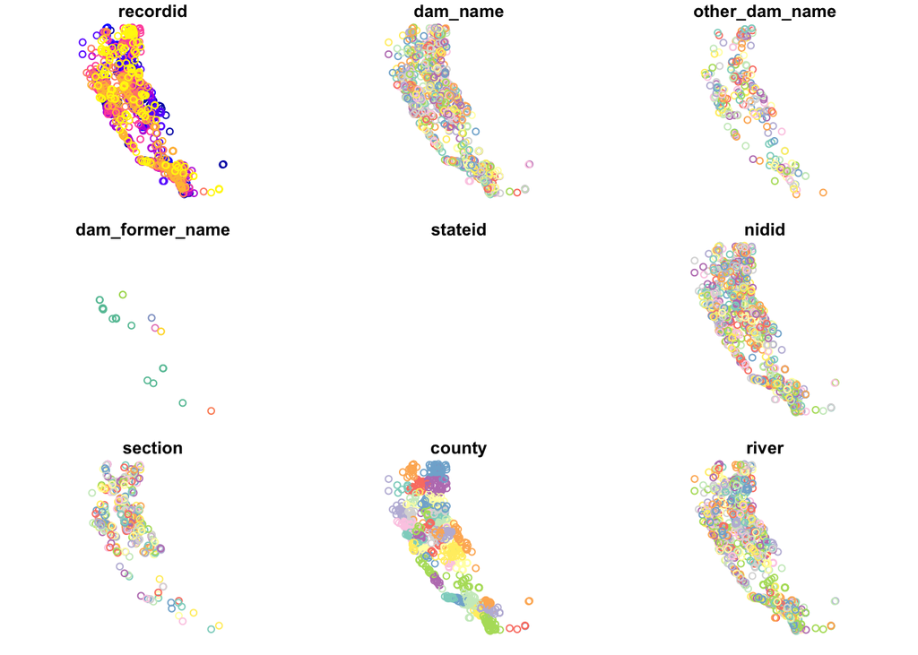

```r
plot(dams_sf)
```

Cool! Now let’s get an outline for California:

# NOTE: GET SAME PROJECTIONS HERE!

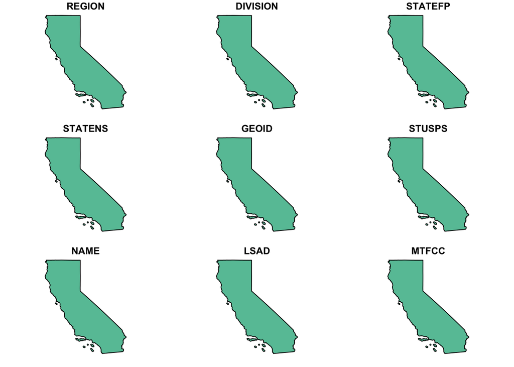

```r
ca_border <- read_sf(here::here("lab_10_materials", "ca_state_border"), layer = "CA_State_TIGER2016")

plot(ca_border)
```

Then plot them together with ggplot2!

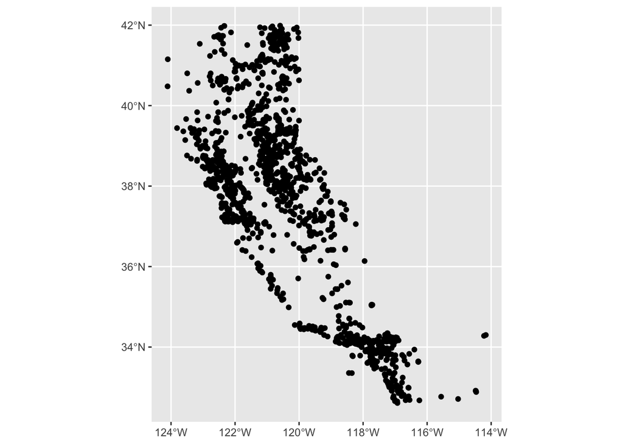

```r
ggplot() +
  geom_sf(data = dams_sf)
```

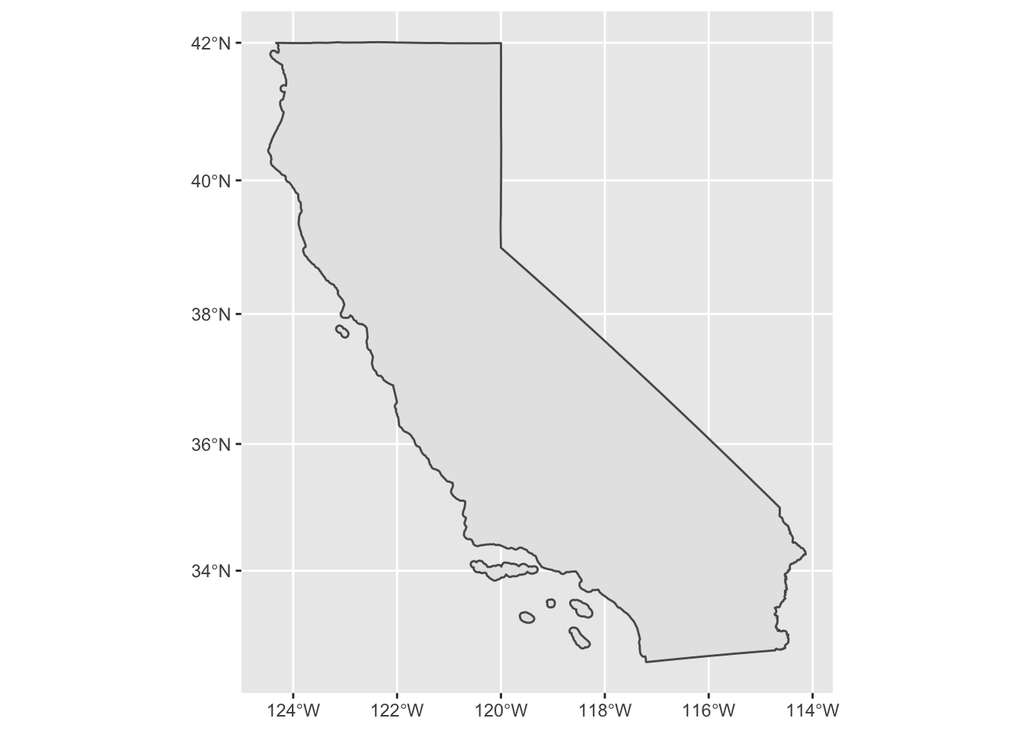

```r
ggplot() +
  geom_sf(data = ca_border)
```

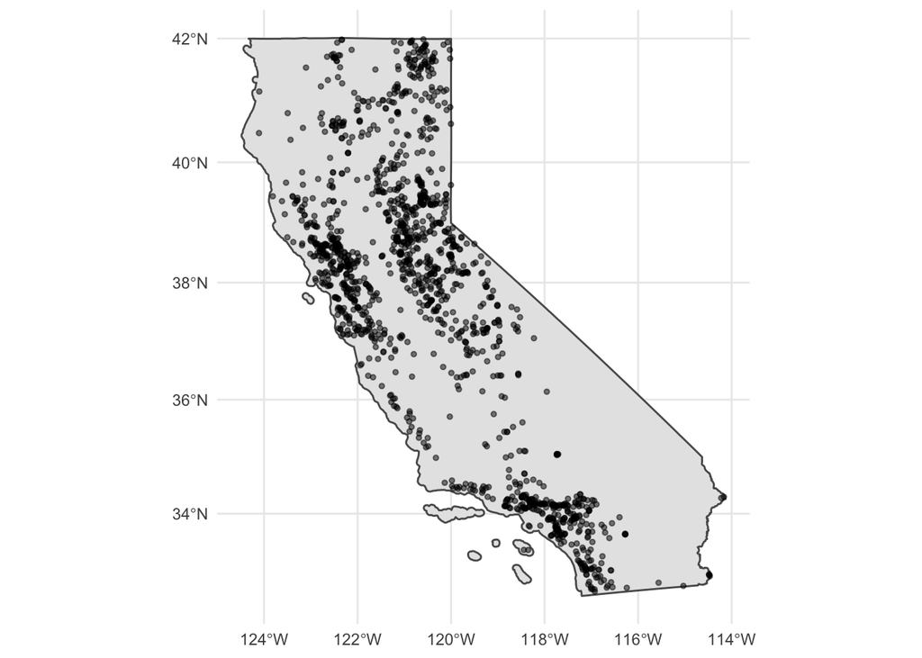

```r
# Combine:
ggplot() +
  geom_sf(data = ca_border) +
  geom_sf(data = dams_sf,
          size = 1,
          alpha = 0.5,
          color = "black") +
  theme_minimal()
```

```r
beepr::beep(8)
```

### 7. A little gganimate teaser

Now show how dams have been added over time with `gganimate`!

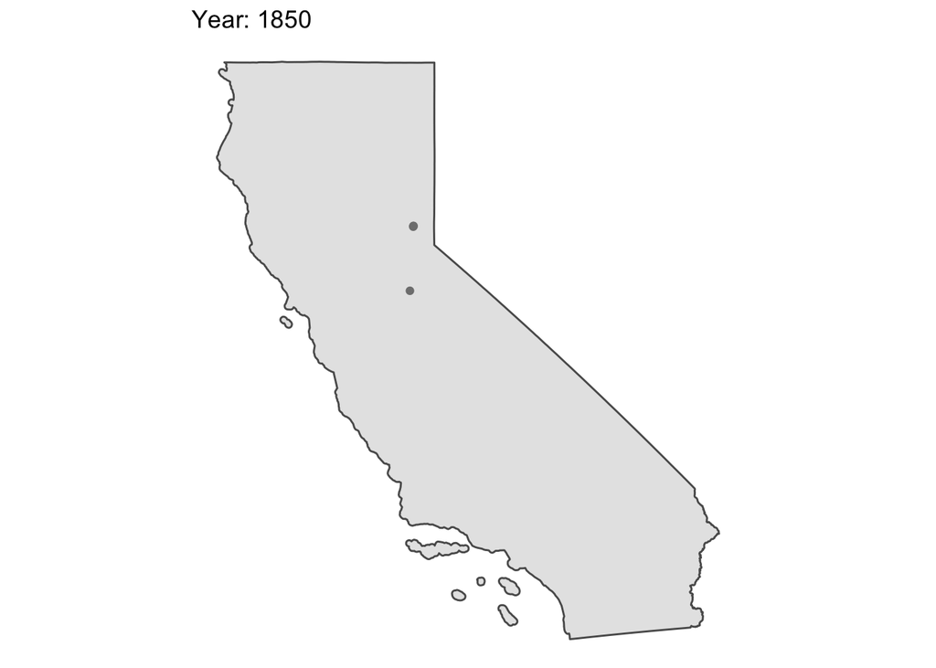

```r
ggplot(data = dams_sf) +
  geom_sf(data = ca_border) +
  geom_sf(data = dams_sf,
          size = 1.5,
          color = "gray50") +
  theme_void() +
  labs(title = 'Year: {round(frame_time,0)}') +
  transition_time(year_completed) +
  shadow_mark(alpha = 1)
```